# Different ways of approaching distance and diffusion

Nicolas Restrepo

1/29/2021

```r
library(tidyverse)
```

```r
library(igraph)
library(brainGraph)
library(patchwork)
library(bayestestR)
```

## Introduction

Farine and Whitehead repeatedly caution against thresholding and I agree with them. Any threshold we can come up with will be, to a certain extent, arbitrary and throwing away information is never a good idea. What we need to figure out then is how we go about tackling cultural diffusion in a principled way whilst keeping all the ties in the network. We need to reflect that - for instance - information is less likely to spread across a tie that has an AI score of 0.1 than through one that has a score of 0.97. I don’t think the measure of global efficiency and our simple contagion simulations are doing this.

## Efficiency in an Association Matrix

Recall that the measure of global efficiency is the average of the inverse distances between all nodes in a network. This can incorporate weights. If I have to go through two ties to reach node j from node i the distance would be the sum of the weights of those two ties. However, in an Association Matrix like the ones we have, where there is a “tie” - no matter how tenuous - between most nodes, the story is more complicated.

Let me provide an example with the elephant data. This nodes 5 to 10 of the matrix:

```r
# Import the data
elephant_data <- read_csv("Data/dist.matrix.t1.csv")
```

```r
# Transform data into square matrix
elephant_matrix <- elephant_data %>%
  select(2:ncol(elephant_data)) %>%
  as.matrix()
# Change the names so that nodes have the same ID as in the dataset
node_IDs <- names(elephant_data)[2:ncol(elephant_data)]
colnames(elephant_matrix) <- node_IDs
rownames(elephant_matrix) <- node_IDs

# Build inverse matrix
inv_elephant_matrix <- matrix(1, 97, 97) - elephant_matrix

# Populate the diagonal with 0s
diag(inv_elephant_matrix) <- 0

# Now create the network
elephant_graph_inv <-
graph_from_adjacency_matrix(inv_elephant_matrix, mode = "undirected", weighted = T)

# Let's see the first three nodes
inv_elephant_matrix[5:10,5:10]
```

```
##            R5          R6        R7          R8        R9         R10
## R5  0.0000000 0.450704225 0.4492754 0.430232558 0.5230769 0.000000000
## R6  0.4507042 0.000000000 0.6724138 0.348314607 0.3913043 0.007874016
## R7  0.4492754 0.672413793 0.0000000 0.329545455 0.4090909 0.000000000
## R8  0.4302326 0.348314607 0.3295455 0.000000000 0.5890411 0.006802721
## R9  0.5230769 0.391304348 0.4090909 0.589041096 0.0000000 0.000000000
## R10 0.0000000 0.007874016 0.0000000 0.006802721 0.0000000 0.000000000
```

Alright, notice that we have some fairly strong associations (R8-R9), some weaker ones (R10-R6), and instances of no ties (R10-R5).

To calculate global efficiency, we need to produce the distances between the nodes. I will that and we will notice some interesting patterns:

```r
# Get the distance matrix
D <- distances(elephant_graph_inv, weights = E(elephant_graph_inv)$weight)

D[5:10,5:10]
```

```
##             R5          R6         R7          R8         R9         R10
## R5  0.00000000 0.012699564 0.01282526 0.011971126 0.01286825 0.014143921
## R6  0.01269956 0.000000000 0.01294620 0.012092074 0.01298920 0.007874016
## R7  0.01282526 0.012946204 0.00000000 0.012217766 0.01311489 0.014516129
## R8  0.01197113 0.012092074 0.01221777 0.000000000 0.01226076 0.006802721
## R9  0.01286825 0.012989203 0.01311489 0.012260765 0.00000000 0.014581694
## R10 0.01414392 0.007874016 0.01451613 0.006802721 0.01458169 0.000000000
```

I am going to find the shortest path between R8 and R9.

```r
# Find shortest path between R8 and R9
all_shortest_paths(elephant_graph_inv, from = 'R8', to = 'R9', mode = 'all')$res
```

```
## [[1]]
## + 3/97 vertices, named, from 7057585:
## [1] R8  M65 R9
```

```r
# Now compare the sum of this entire path
inv_elephant_matrix['R8', 'M65']
```

```
## [1] 0.005681818
```

```r
inv_elephant_matrix['R9', 'M65']
```

```
## [1] 0.006578947
```

The algorithm takes two almost non-existent ties and sums together. This is heavily penalizing ties that are actually strong, imagining that weight is distance.

Maybe then we should use the matrix as originally stored, where 1 was zero association. We can replace the 1s though, as we are confident there is no tie there.

```r
# Replace 1s with 0s
elephant_matrix[elephant_matrix==1] <- 0

# Create graph
eg_regular <- graph_from_adjacency_matrix(elephant_matrix, mode = "undirected", weighted = T)

# Distance for this graph
D <- distances(eg_regular, weights = E(eg_regular)$weight)

D[5:10, 5:10]
```

```
##            R5        R6        R7        R8        R9       R10
## R5  0.0000000 0.5492958 0.5507246 0.5697674 0.4769231 1.5414218
## R6  0.5492958 0.0000000 0.3275862 0.6516854 0.6086957 0.9921260
## R7  0.5507246 0.3275862 0.0000000 0.6704545 0.5909091 1.3197122
## R8  0.5697674 0.6516854 0.6704545 0.0000000 0.4109589 0.9931973
## R9  0.4769231 0.6086957 0.5909091 0.4109589 0.0000000 1.4041562
## R10 1.5414218 0.9921260 1.3197122 0.9931973 1.4041562 0.0000000
```

Now, this makes a lot more sense! While R8 and R9 are relatively close, R10 and R5 (that have no direct tie between them) are quite far apart.

Perhaps calculating efficiency on these distances makes a lot more sense.

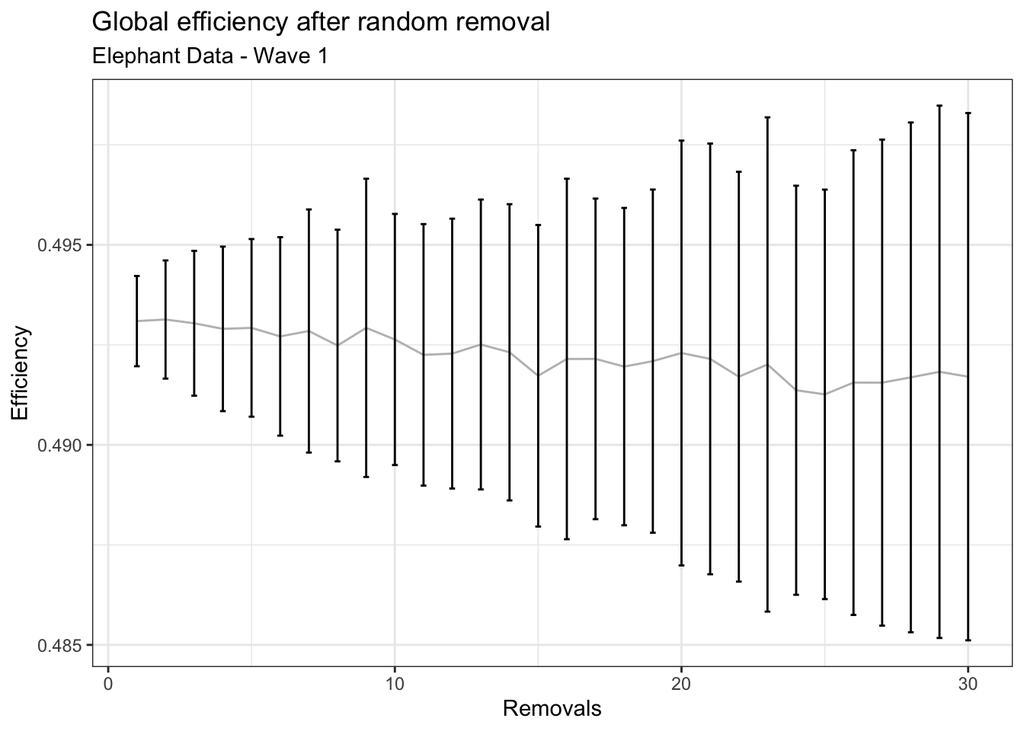

```r
# Our function for efficiency after removal
efficiency_after_random_removal <- function(g, reps, num_removals) {
  # placeholder
  efficiencies <- rep(NA, reps)

  for (i in 1:reps) {
    rmv <- sample(1:vcount(g), num_removals)
    ng <- delete.vertices(g,rmv)
    D <- distances(ng,
               weights = E(ng)$weight)
    D <- D + 1
    diag(D) <- 0
    Nv <- nrow(D)
    Dinv <- 1/D
    eff <- colSums(Dinv * is.finite(Dinv), na.rm = T)/(Nv - 1)
    geff <- sum(eff)/length(eff)
    efficiencies[i] <- geff
  }
  avg_eff <- mean(efficiencies)
  sd_eff <- sd(efficiencies)
  upper <- avg_eff + 1.96*sd_eff
  lower <- avg_eff - 1.96*sd_eff
  return(c(avg_eff = avg_eff,
           upper = upper,
           lower = lower,
           removals = num_removals))
}

# Dataset for eff at different levels of removal
elephant_rr_df <- map_df(c(1:30),
                    efficiency_after_random_removal,
                        g=eg_regular,
                        reps = 100)

elephant_rr_df %>%
  ggplot(aes(x = removals, y = avg_eff)) +
  geom_line(color = "gray") +
  geom_errorbar(aes(ymin = lower, ymax = upper), width = 0.2) +
  theme_bw() +
  labs(title = "Global efficiency after random removal",
       subtitle = "Elephant Data - Wave 1",
       x = "Removals",
       y = "Efficiency")
```

We notice that though the central tendency remains similar, the variance increases considerably. Here, we have instances where removing random nodes considerably affects the efficiency of the graph. It may increase it by removing loosely connected nodes or decrease it by removing paths that were linking different clusters.

Let’s see how this new way of conceptualizing distance affects centrality-based removal. The difference here is that I am going to consider efficiency using the data as is (with the inverse distances) but I will assess centrality using the reverse-coded network.

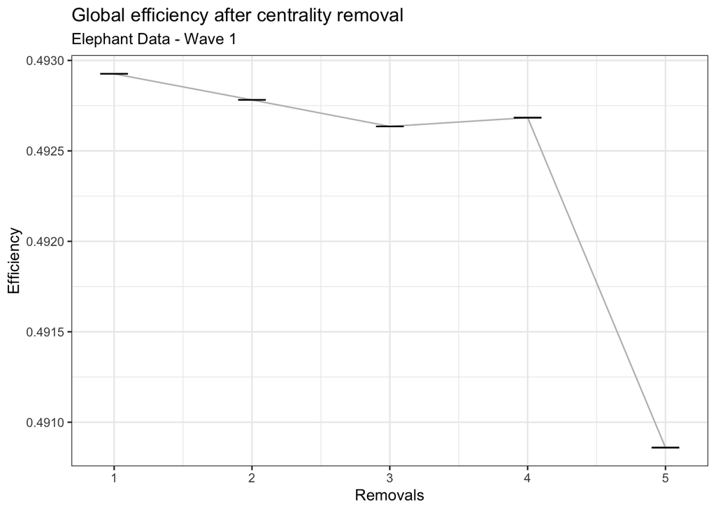

```r
# Write a function for removal of central nodes
efficiency_after_centrality_removal <- function(g, reps, num_removals, cent_scores) {
  # placeholder
  efficiencies <- rep(NA, reps)

  for (i in 1:reps) {
    centrality <- cent_scores
    centrality <- sort(centrality, decreasing = T)
    central_nodes <- names(centrality)
    ng <- delete.vertices(g,central_nodes[1:num_removals])
    D <- distances(ng,
               weights = E(ng)$weight)
    D <- D + 1
    diag(D) <- 0
    Nv <- nrow(D)
    Dinv <- 1/D
    eff <- colSums(Dinv * is.finite(Dinv), na.rm = T)/(Nv - 1)
    geff <- sum(eff)/length(eff)
    efficiencies[i] <- geff
  }
  avg_eff <- mean(efficiencies)
  sd_eff <- sd(efficiencies)
  upper <- avg_eff + 1.96*sd_eff
  lower <- avg_eff - 1.96*sd_eff
  return(c(avg_eff = avg_eff,
           upper = upper,
           lower = lower,
           removals = num_removals))
}

# Dataset for eff at different levels of removal
elephant_rr_df <- map_df(c(1:5),
                    efficiency_after_centrality_removal,
                        g=eg_regular,
                        reps = 100,
                    cent_scores = eigen_centrality(elephant_graph_inv)$vector)

elephant_rr_df %>%
  ggplot(aes(x = removals, y = avg_eff)) +
  geom_line(color = "gray") +
  geom_errorbar(aes(ymin = lower, ymax = upper), width = 0.2) +
  theme_bw() +
  labs(title = "Global efficiency after centrality removal",
       subtitle = "Elephant Data - Wave 1",
       x = "Removals",
       y = "Efficiency")
```

In general the efficiency does go down, but the decrease is only slight. There is not a considerable drop until we remove the fifth most central node of the network and even then the difference is relatively small.

## Diffusion and Weights

Let’s see whether this specification changes trajectories of diffusion.

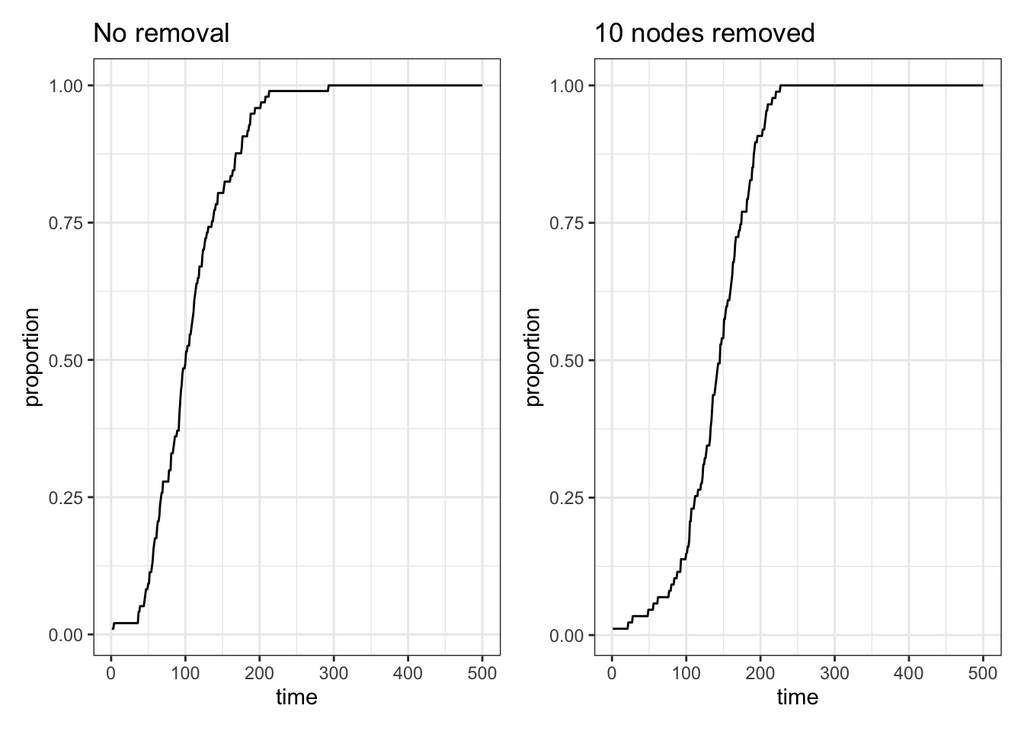

```r
# Contagion model from Acerbi et al (2020)
info_contagion <- function(net, rewire, e = 1, r_max, sim = 1){

  # Rewire network if random is set to TRUE
  if(rewire){
    net <- rewire(graph = net, with = keeping_degseq(loops = F, niter = 10^3))
  }

  # Get adjacency matrix from network
  adjm <- get.adjacency(net,
                        sparse = F,
                        attr = "weight")

  # Turn adjacency matrix into boolean (TRUE / FALSE) - if you dont want weights
  # adjm_bool <- adjm > 0

  # Set number of individuals based adjacency matrix
  N <- vcount(net)

  # Create a vector indicating possession of info and set one entry to TRUE
  info <- rep(FALSE, N)
  info[sample(x = N, size = 1)] <- TRUE

  # Create a reporting variable
  proportion <- rep(0, r_max)

  # Rounds
  for(r in 1:r_max){
    # In random sequence go through all individuals without info
    for(i in sample(N)){
      # Select i's neighbourhood
      nei <- adjm[i,] > 0
      # If you dont want to include weights, quote above, unquote below
      #nei <- adjm_bool[i,]
      # Proceed if there is at least one neighbour
      if(sum(nei) > 0){
        # Simple contagion for e = 1 and complex contagion for e = 2
        if(runif(n = 1, min = 0, max = 1) <= (sum(adjm[i,][info])/length(nei))^e){
          info[i] <- TRUE
        }
      }
    }
    # Record proportion of the population with info
    proportion[r] <- sum(info) / N
    # Increment the round counter
    r <- r + 1
  }
  # Return a tibble with simulation results
  return(tibble(time = 1:r_max,
                proportion = proportion,
                time_to_max = which(proportion == max(proportion))[1],
                e = e,
                network = ifelse(test = rewire, yes = "random", no = "model output"),
                sim = sim))
}

# Contagion with no removal
e_sim_nr <- info_contagion(elephant_graph_inv,
                           rewire = F,
                           e = 1,
                           r_max = 500)

p1 <- e_sim_nr %>%
  ggplot(aes(x = time, y = proportion)) +
  geom_line() +
  theme_bw() +
  labs(title = "No removal")

# Now some random removal
rmv <- sample(1:vcount(elephant_graph_inv), 10)
ng <- delete.vertices(elephant_graph_inv, rmv)


# Contagion with random removal
e_sim_r <- info_contagion(ng,
                           rewire = F,
                           e = 1,
                           r_max = 500)

p2 <- e_sim_r %>%
  ggplot(aes(x = time, y = proportion)) +
  geom_line() +
  theme_bw() +
  labs(title = "10 nodes removed")

p1 + p2
```

First, notice that the behavior takes now a lot longer to spread. Second, we see that the spread is slower when nodes have been removed. This is perhaps more like what we expected from these simulations.

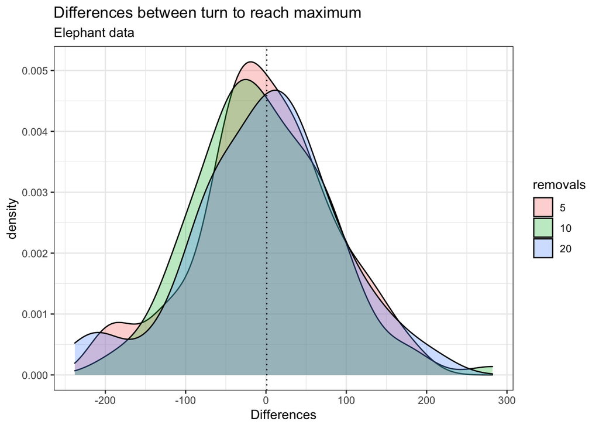

```r
turn_reached_max <- function(ev, g, reps, turns, num_removals) {
  # Place holder
  values <- rep(NA, reps)

  for (i in 1:reps) {
    sim <- info_contagion(g,
                          rewire = F,
                          e = ev,
                          r_max = turns)
    ttm <- sim$time_to_max[1]

    # Now some random removal
    rmv <- sample(1:vcount(g), num_removals)
    ng <- delete.vertices(g, rmv)
    sim_r <- info_contagion(ng,
                            rewire = F,
                            e = ev,
                            r_max = turns)
    ttmr <- sim_r$time_to_max[1]

    values[i] <- ttm-ttmr
  }
  return(values)
}

diffs_10_rems <- turn_reached_max(ev = 1,
                 g = elephant_graph_inv,
                 reps = 100,
                 turns = 500,
                 num_removals = 10)
diffs_20_rems <- turn_reached_max(ev = 1,
                 g = elephant_graph_inv,
                 reps = 100,
                 turns = 500,
                 num_removals = 20)
diffs_5_rems <- turn_reached_max(ev = 1,
                 g = elephant_graph_inv,
                 reps = 100,
                 turns = 500,
                 num_removals = 5)

aucs_elephant <- tibble(ratios = c(diffs_5_rems, diffs_10_rems, diffs_20_rems),
                        removals = rep(c(5, 10, 20), each = 100)) %>%
  mutate(removals = as.factor(removals))

aucs_elephant %>%
  ggplot(aes(x = ratios, fill = removals)) +
  geom_density(alpha = 0.3) +
  geom_vline(xintercept = 1, linetype = 3) +
  theme_bw() +
  labs(title = "Differences between turn to reach maximum",
       subtitle = "Elephant data",
       x = "Differences")
```

The distributions are squarely centered around one. Even with our new recoding of the diffusion function, it seems like the random removal of nodes does not have a huge impact on how quickly a trait diffuses across the network.

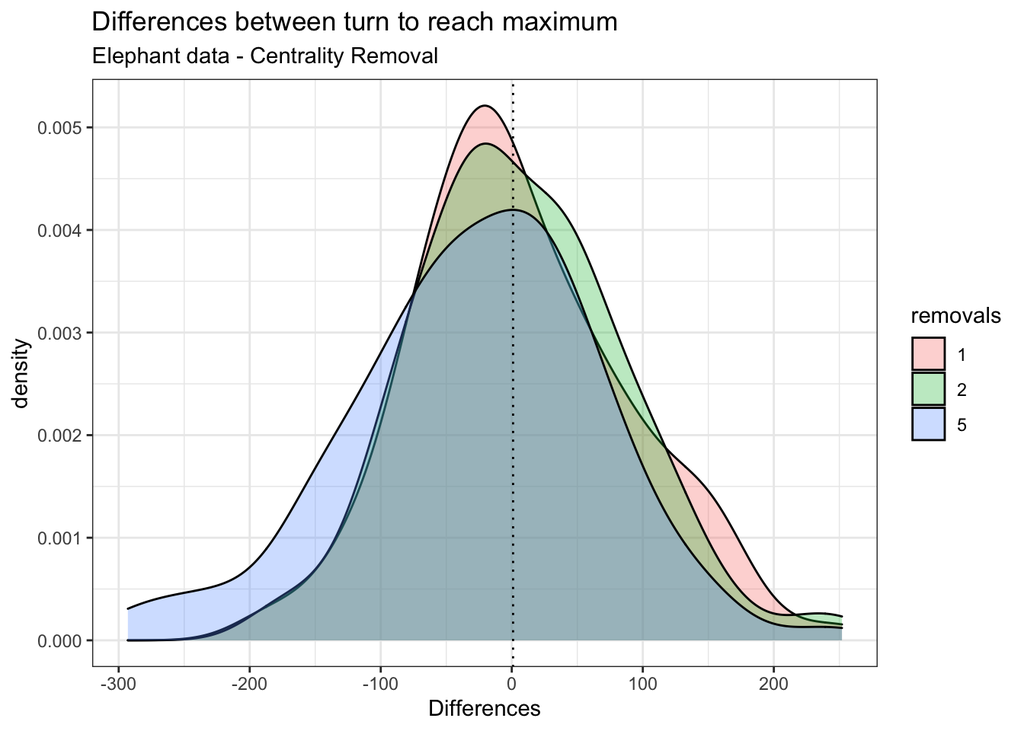

```r
turn_reached_max_centrality <- function(ev, g, reps, turns, num_removals) {
  # Place holder
  values <- rep(NA, reps)

  for (i in 1:reps) {
    sim <- info_contagion(g,
                          rewire = F,
                          e = ev,
                          r_max = turns)
    ttm <- sim$time_to_max[1]

    # Now some centrality removal
    centrality <- eigen_centrality(g)$vector
    centrality <- sort(centrality, decreasing = T)
    central_nodes <- names(centrality)
    ng <- delete.vertices(g,central_nodes[1:num_removals])
    sim_r <- info_contagion(ng,
                            rewire = F,
                            e = ev,
                            r_max = turns)
    ttmr <- sim_r$time_to_max[1]

    values[i] <- ttm-ttmr
  }
  return(values)
}

diffs_5_rems <- turn_reached_max_centrality(ev = 1,
                 g = elephant_graph_inv,
                 reps = 100,
                 turns = 500,
                 num_removals = 5)
diffs_2_rems <- turn_reached_max_centrality(ev = 1,
                 g = elephant_graph_inv,
                 reps = 100,
                 turns = 500,
                 num_removals = 2)
diffs_1_rems <- turn_reached_max_centrality(ev = 1,
                 g = elephant_graph_inv,
                 reps = 100,
                 turns = 500,
                 num_removals = 1)

aucs_elephant <- tibble(ratios = c(diffs_5_rems, diffs_1_rems, diffs_2_rems),
                        removals = rep(c(5, 1, 2), each = 100)) %>%
  mutate(removals = as.factor(removals))

aucs_elephant %>%
  ggplot(aes(x = ratios, fill = removals)) +
  geom_density(alpha = 0.3) +
  geom_vline(xintercept = 1, linetype = 3) +
  theme_bw() +
  labs(title = "Differences between turn to reach maximum",
       subtitle = "Elephant data - Centrality Removal",
       x = "Differences")
```

Centrality-based removal also does not seem to have a huge impact in how quickly or slowly a trait spreads across the network.